# Review Analysis Tests: Tables on Review Length Test and Review Count Test by Product

Eugenie

19/10/2019

# 1 Load Source File

Data pre-processing is included, where special chars and minimal stop-words are removed.

```r
library(data.table)
## load review data
source("~/Dropbox/Eugenie/scripts/libs.R")
```

Load data.

# 2 Data Processing

# 3 Analysis Test: Daily Average Review Count

## 3.1 Data Processing

## 3.2 Result Analysis

### 3.2.1 Two standard deviations away

| product_cat | Freq.before_pass | Freq.after_pass | Freq.before_fail | Freq.after_fail | Before.fail.pct | After.fail.pct |
| --- | --- | --- | --- | --- | --- | --- |
| cell_phones | 2576 | 23273 | 633 | 9067 | 19.72577 | 28.036487 |
| phone_batteries | 23913 | 41340 | 4878 | 18531 | 16.94279 | 30.951546 |
| phone_cables | 17117 | 25129 | 3606 | 22665 | 17.40096 | 47.422271 |
| screen_protectors | 9841 | 41665 | 1441 | 29067 | 12.77256 | 41.094554 |
| tablets | 69916 | 212938 | 11092 | 13340 | 13.69247 | 5.895403 |

Mean review rating for over vs. under daily threshold for the number of reviews.

| product_cat | avg.rating.pass | avg.rating.fail |
| --- | --- | --- |
| cell_phones | 3.798251 | 3.446083 |
| phone_batteries | 4.322713 | 4.415866 |
| phone_cables | 4.403873 | 4.511743 |
| screen_protectors | 4.085019 | 4.203848 |
| tablets | 4.074827 | 4.182752 |

Review distribution between groups.

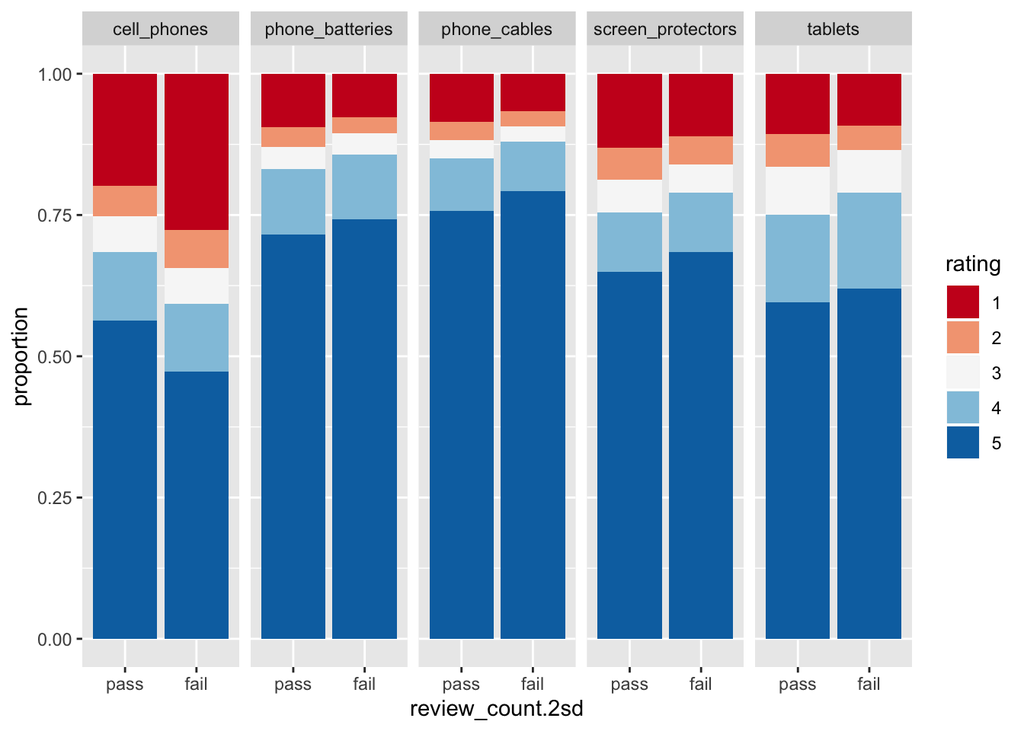

Linear Regression with Fixed Effect on Item ID

**Linear Regression with Fixed Effect: Daily Review Count**

|  | *Dependent variable:* |
| --- | --- |
|  | rating |
| review_count.2sdfail | 0.109*** |
|  | (0.006) |
| Observations | 582,028 |
| R<sup>2</sup> | 0.001 |
| Adjusted R<sup>2</sup> | 0.0002 |
| F Statistic | 348.461*** (df = 1; 581796) |
| *Note:* | p<0.1; p<0.05; p<0.01 |

From the result of the linear fixed effect modelling, the null hypothesis of the independency of products is rejected.

### 3.2.2 Three standard deviations away

| product_cat | Freq.before_pass | Freq.after_pass | Freq.before_fail | Freq.after_fail | Before.fail.pct | After.fail.pct |
| --- | --- | --- | --- | --- | --- | --- |
| cell_phones | 3050 | 24281 | 159 | 8059 | 4.954815 | 24.919604 |
| phone_batteries | 27015 | 48606 | 1776 | 11265 | 6.168594 | 18.815453 |
| phone_cables | 19101 | 30767 | 1622 | 17027 | 7.827052 | 35.625811 |
| screen_protectors | 10799 | 47586 | 483 | 23146 | 4.281156 | 32.723520 |
| tablets | 73775 | 217143 | 7233 | 9135 | 8.928748 | 4.037069 |

Mean review rating for over vs. under daily threshold for the number of reviews.

| product_cat | avg.rating.pass | avg.rating.fail |
| --- | --- | --- |
| cell_phones | 3.781420 | 3.438550 |
| phone_batteries | 4.332672 | 4.432175 |
| phone_cables | 4.424581 | 4.500456 |
| screen_protectors | 4.088996 | 4.228617 |
| tablets | 4.075791 | 4.218781 |

Review distribution between groups.

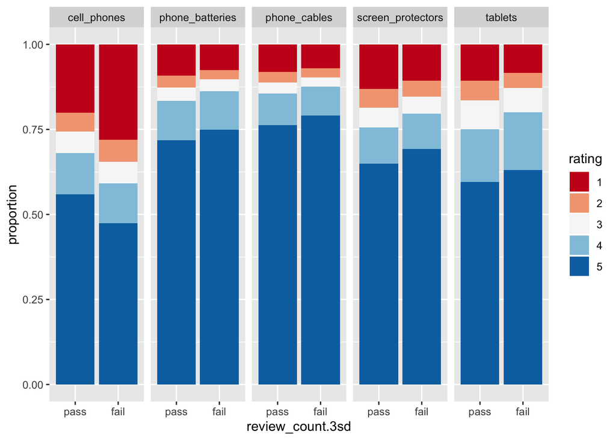

Linear Regression with Fixed Effect on Item ID

**Linear Regression with Fixed Effect: Daily Review Count**

|  | *Dependent variable:* |
| --- | --- |
|  | rating |
| review_count.3sdfail | 0.121*** |
|  | (0.007) |
| Observations | 582,028 |
| R<sup>2</sup> | 0.001 |
| Adjusted R<sup>2</sup> | 0.0001 |
| F Statistic | 303.377*** (df = 1; 581796) |
| *Note:* | p<0.1; p<0.05; p<0.01 |

From the result of the linear fixed effect modelling, the null hypothesis of the independency of products is rejected.

# 4 Analysis Test: Average Review Length

Once we have the word count distribution of the product and the expected distribution of the category we compare the two distributions and identify product word count groups that are higher in concentration than we’d expect to see.

## 4.1 Data Processing

## 4.2 Result Analysis

### 4.2.1 Two standard deviations away

| product_cat | Freq.before_fail | Freq.after_fail | Freq.before_pass | Freq.after_pass | Before.fail.pct | After.fail.pct | mean | variance | sd | threshold_2sd |
| --- | --- | --- | --- | --- | --- | --- | --- | --- | --- | --- |
| cell_phones | 99 | 2054 | 3110 | 30286 | 3.085073 | 6.3512678 | 29.18760 | 2488.654 | 49.88641 | 128.9604 |
| phone_batteries | 1034 | 766 | 27757 | 59105 | 3.591400 | 1.2794174 | 40.56764 | 5079.345 | 71.26952 | 183.1067 |
| phone_cables | 850 | 337 | 19873 | 47457 | 4.101723 | 0.7051094 | 36.82517 | 4060.064 | 63.71864 | 164.2624 |
| screen_protectors | 510 | 559 | 10772 | 70173 | 4.520475 | 0.7903071 | 48.24233 | 5075.690 | 71.24388 | 190.7301 |
| tablets | 2461 | 4789 | 78547 | 221489 | 3.037972 | 2.1164232 | 38.16413 | 5218.913 | 72.24204 | 182.6482 |

Review length after ban.

| product_cat | sd | variance | mean |
| --- | --- | --- | --- |
| cell_phones | 84.79526 | 7190.2360 | 43.48482 |
| phone_batteries | 43.62283 | 1902.9513 | 33.37800 |
| phone_cables | 30.78219 | 947.5433 | 22.96069 |
| screen_protectors | 38.30201 | 1467.0437 | 27.50479 |
| tablets | 57.00735 | 3249.8382 | 34.69463 |

Mean review rating for over vs. under length threshold for the number of reviews.

| product_cat | avg.rating.fail | avg.rating.pass |
| --- | --- | --- |
| cell_phones | 3.509057 | 3.714606 |
| phone_batteries | 4.463889 | 4.344892 |
| phone_cables | 4.407751 | 4.445893 |
| screen_protectors | 4.063611 | 4.130088 |
| tablets | 3.205793 | 4.104614 |

Review distribution between groups.

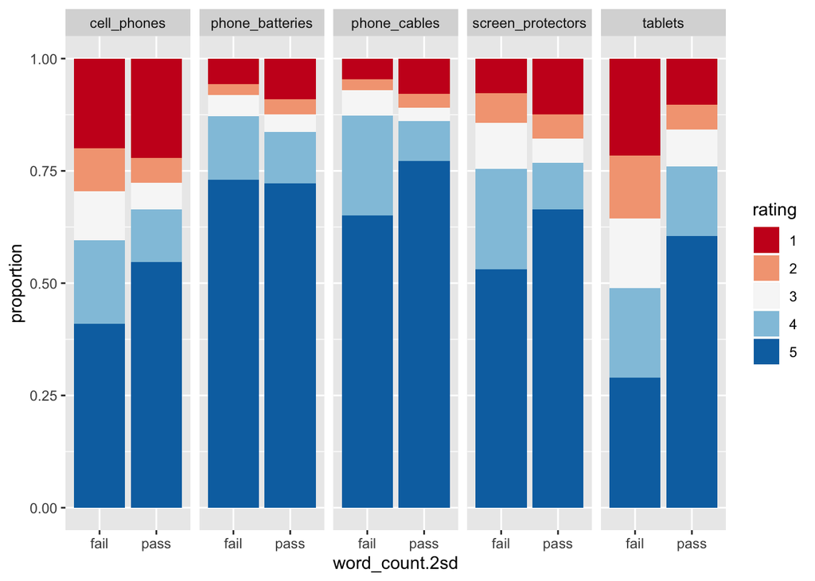

### 4.2.2 Three standard deviations away

| product_cat | Freq.before_fail | Freq.after_fail | Freq.before_pass | Freq.after_pass | Before.fail.pct | After.fail.pct | mean | variance | sd | threshold_3sd |
| --- | --- | --- | --- | --- | --- | --- | --- | --- | --- | --- |
| cell_phones | 53 | 1163 | 3156 | 31177 | 1.651605 | 3.5961657 | 29.18760 | 2488.654 | 49.88641 | 178.8468 |
| phone_batteries | 578 | 282 | 28213 | 59589 | 2.007572 | 0.4710127 | 40.56764 | 5079.345 | 71.26952 | 254.3762 |
| phone_cables | 441 | 121 | 20282 | 47673 | 2.128070 | 0.2531699 | 36.82517 | 4060.064 | 63.71864 | 227.9811 |
| screen_protectors | 253 | 223 | 11029 | 70509 | 2.242510 | 0.3152746 | 48.24233 | 5075.690 | 71.24388 | 261.9740 |
| tablets | 1261 | 2282 | 79747 | 223996 | 1.556636 | 1.0084940 | 38.16413 | 5218.913 | 72.24204 | 254.8903 |

Mean review rating for over vs. under length threshold for the number of reviews.

| product_cat | avg.rating.fail | avg.rating.pass |
| --- | --- | --- |
| cell_phones | 3.604441 | 3.705618 |
| phone_batteries | 4.546512 | 4.345357 |
| phone_cables | 4.451957 | 4.445177 |
| screen_protectors | 4.151261 | 4.129093 |
| tablets | 3.273779 | 4.092852 |

Review distribution between groups.

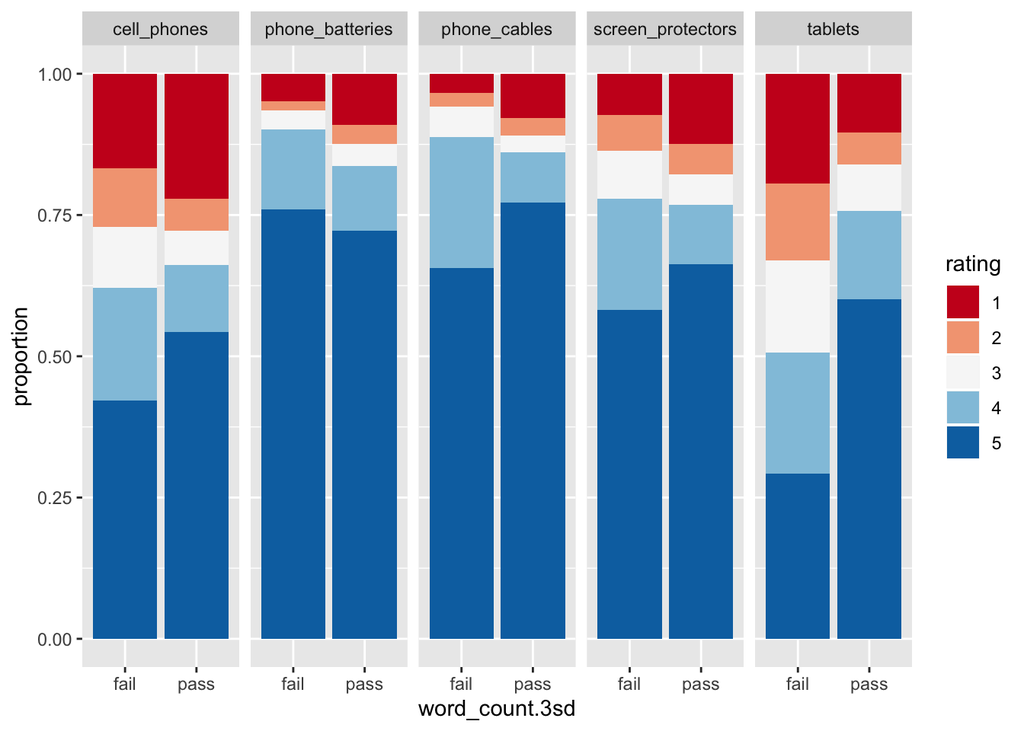